# Linear Models I

If the system prompts you to install a package, or gives you a “package not found” error, simply run `install.packages("packagename")` once to install it.

If you get a “[packagename] not installed” error, run `py_install("packagename")` in your **console**.

# The Dataset

Today we will use a dataset containing counts of babies born in California with the name “Kelly” between 1989 and 2016. Run the chunk below to load the data, and to check out the first few rows of your dataset.

```python
kelly_df = pd.read_csv("https://www.dropbox.com/s/p3dez3ug5fquygh/kellys_ca.csv?dl=1")
kelly_df.head()
```

```
##   State Gender  Year   Name  Count
## 0    CA      F  1989  Kelly    920
## 1    CA      F  1990  Kelly    929
## 2    CA      F  1991  Kelly    785
## 3    CA      F  1992  Kelly    800
## 4    CA      F  1993  Kelly    703
```

The first thing we need to do with any dataset is check for missing data, and make sure the variables are the right type:

```python
kelly_df.info()
```

```
## <class 'pandas.core.frame.DataFrame'>
## RangeIndex: 56 entries, 0 to 55
## Data columns (total 5 columns):
##  #   Column  Non-Null Count  Dtype
## ---  ------  --------------  -----
##  0   State   56 non-null     object
##  1   Gender  56 non-null     object
##  2   Year    56 non-null     int64
##  3   Name    56 non-null     object
##  4   Count   56 non-null     int64
## dtypes: int64(2), object(3)
## memory usage: 2.3+ KB
```

Looks good for this data, with one exception:

The “Gender” variable is being treated as an “object” variable, i.e., just an ordinary word.

But we know it should be *categorical*, aka a *factor* variable. Let’s retype the variable to fix this:

```python
kelly_df['Gender'] = kelly_df['Gender'].astype('category')
kelly_df.info()
```

```
## <class 'pandas.core.frame.DataFrame'>
## RangeIndex: 56 entries, 0 to 55
## Data columns (total 5 columns):
##  #   Column  Non-Null Count  Dtype
## ---  ------  --------------  -----
##  0   State   56 non-null     object
##  1   Gender  56 non-null     category
##  2   Year    56 non-null     int64
##  3   Name    56 non-null     object
##  4   Count   56 non-null     int64
## dtypes: category(1), int64(2), object(2)
## memory usage: 2.0+ KB
```

The next thing we should do is visualize our variables to get a feel for what is going on in this data.

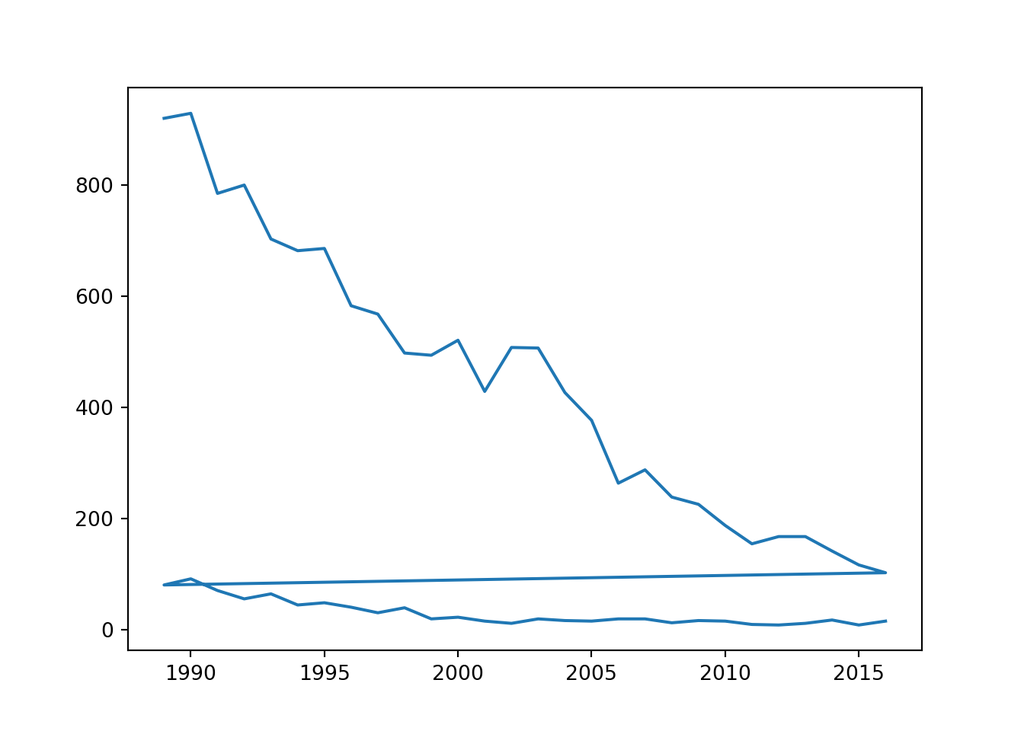

```python
plt.plot(kelly_df['Year'], kelly_df['Count'])
plt.show()
```

Hmmm…. clearly there is some kind of linear-ish decreasing trend in number of Kellys. But what’s going on with the two separate lines?

## Fitting a model

Let’s begin with a simple linear model. We will focus only on the female-assigned Kelly babies for now.

```python
kellys_fem = kelly_df[kelly_df['Gender'] == "F"]
```

Our first step is to establish a which model(s) we want to try on the data.

For now, this is just a simple linear model.

```python
lin_reg = LinearRegression()
```

Next, we will **fit** the model to our data:

```python
lin_reg.fit(X = kellys_fem[['Year']], y = kellys_fem['Count'])
```

```
## LinearRegression()
```

Let’s check out the output of this model fit:

```python
lin_reg.coef_
```

```
## array([-29.96743295])
```

How do we interpret this?

## Residuals

Now let’s look the residuals of the model.

First, we can find out what values were predicted by the model:

```python
preds = lin_reg.predict(kellys_fem[['Year']])
```

Then, we can calculate and visualize the residuals:

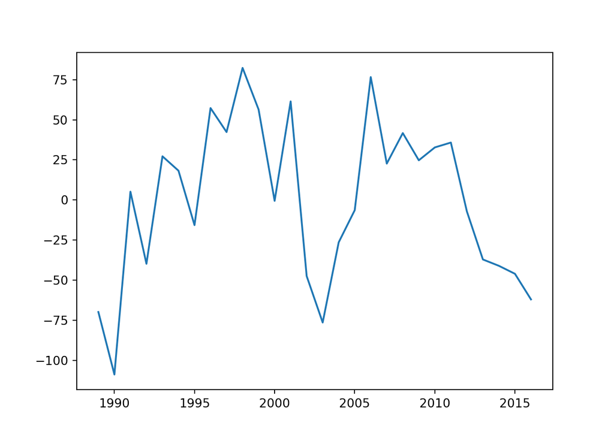

```python
resids = preds - kellys_fem['Count']

plt.plot(kellys_fem['Year'], resids)
plt.show()
```

Do the residuals seem to represent “random noise”?

That is, was our choice of model reasonable?

## Metrics

If we are trying to find the “best” model, we should measure how well this one did.

We can compute the SSE and MSE “by hand”:

```python
sum(resids**2)
```

```
## 67527.0265462508
```

```python
sum(resids**2)/28
```

```
## 2411.679519508957
```

# YOUR TURN

What about Gender? Is the pattern of decreasing Kelly babies the same for the two Genders? Can you include Gender in the model, and interpret the results?

With your group, create a new notebook (you can copy this one if you want), and fit a model using both Year *and* Gender as predictors. Report your results.